# Text Mining Leadership Survey: Cleaning & Exploration

Oct 12, 2017

## Overview

This RMarkdown file is an annotated R code that combines written text with R code along with the accompanying output. This code is rendered into a HTML file to allow users to view the code and output without having to run the code individually.

Users without any experience in RMarkdown, should consult R Studio’s [RMarkdown tutorial](http://rmarkdown.rstudio.com/lesson-1.html) lessons on how to run the code.

Users without any experience in [quanteda](http://quanteda.io/index.html), should consider first reviewing its [Getting Started](http://quanteda.io/articles/quickstart.html) tutorial. This will provide context of many terms and functions used in this document and is especially critical for users without experience in computer assisted text analysis or natural language processing.

Further, this resource references many functions from [tidyverse](https://www.tidyverse.org/), the standard library of R packages and users are expected to have some knowledge of the most critical aspects (e.g., dplyr, piping). Users without any experience should consider one of many resources [for example, here](https://www.tidyverse.org/learn/) to learn the most basic tidyverse functions.

## Design & Data Collection

### Load the data

First, let’s load the data. We’ll use the `readr` package that is embedded in the `tidyverse` package.

```r
library(tidyverse)  #install.packages('tidyverse') if you do not have the package

file <- "./TMM_FullDataset.csv"
responses <- read_csv(file)
```

This file includes 753 records and 52 columns.

### Invalid Records

Let’s remove any invalid records for users who did not complete the survey.

For example, let’s explore the “Progress” field that shows the percentage of completion.

```r
responses %>% group_by(Progress) %>% summarise(Count = n())
```

```
## # A tibble: 5 x 2
##   Progress Count
##      <int> <int>
## 1        7    15
## 2       29   147
## 3       40     4
## 4       43     2
## 5      100   585
```

So only 585 of the 753 records were completed (i.e. 100 = 100%).

Let’s use the `filter` function to keep completed responses (i.e. Progress = 100%).

```r
responses <- filter(responses, Progress == 100)
```

### Text Quality

Let’s look at a few examples to determine the quality of the responses (e.g., misspellings, grammatical mistakes).

```r
responses$Q4[1:3]
```

```
## [1] "I was at work and I asked my supervisor what to do about a particular problem.  She said not to worry about it and we'd get to it later.  I then got chewed out by the boss because I left the problem unfixed.  I felt bad because I should have stuck up for myself.  I just let that girl throw m…
## [2] "We have a great relationship. Whenever I need help with anything I can rely on his knowledge and expertise to help me out. He is available on call at any time. He shows me respect by letting me have freedom and autonomy. In other words he trusts me and does not micromanage. My relationship w…
## [3] "I almost never speak with him. he does not know what i do and couldn't give me any coaching if he tried. but thankfully, he does not even try. My relationship with him is the same as with my previous manager - it is virtually nonexistent. That means that we barely ever interact other than at…
```

First, it looks like these responses are written in clear English – unlike Tweets that use slang or abbreviations. Some responses do not have perfect grammar (e.g. sample 3: “him. he does not”), but this is a minor problem. We will standardize responses by converting all letters into lower case and removing punctuation in our pre-processing.

`quanteda` also offers a helpful `textstat_readability` function to measure many different indexes (47 different types) of readability (e.g. Flesch.Kincaid). For more information, please see [Flesch-Kincaid readability test Wikipedia page](https://en.wikipedia.org/wiki/Flesch%E2%80%93Kincaid_readability_tests).

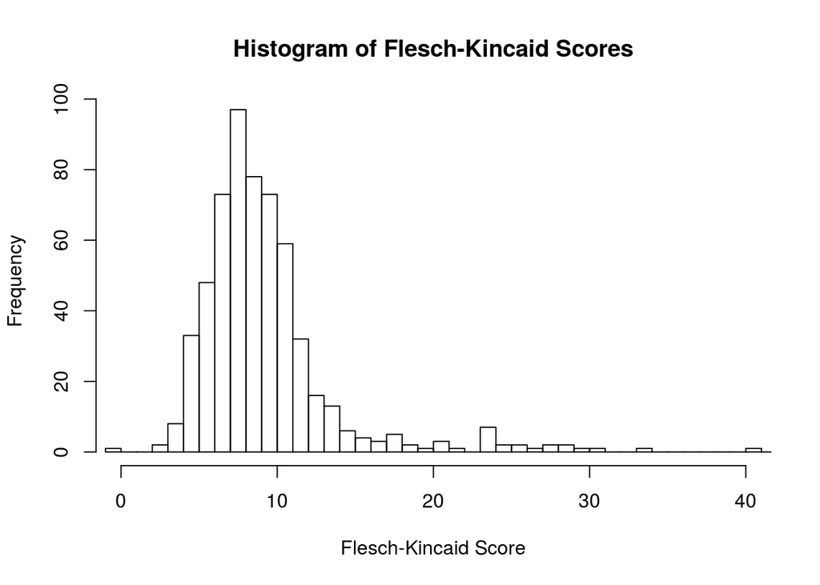

```r
library(quanteda)
readability <- textstat_readability(responses$Q4)

hist(readability$Flesch.Kincaid, xlim = c(0, 40), breaks = 200, xlab = "Flesch-Kincaid Score",
    main = "Histogram of Flesch-Kincaid Scores")
```

### Length of responses

Let’s explore the histogram of tokens (i.e., words). We will look at the total number of tokens. (Alternatively, you can view the number of unique tokens by changing the function `ntoken()` to `ntype()`).

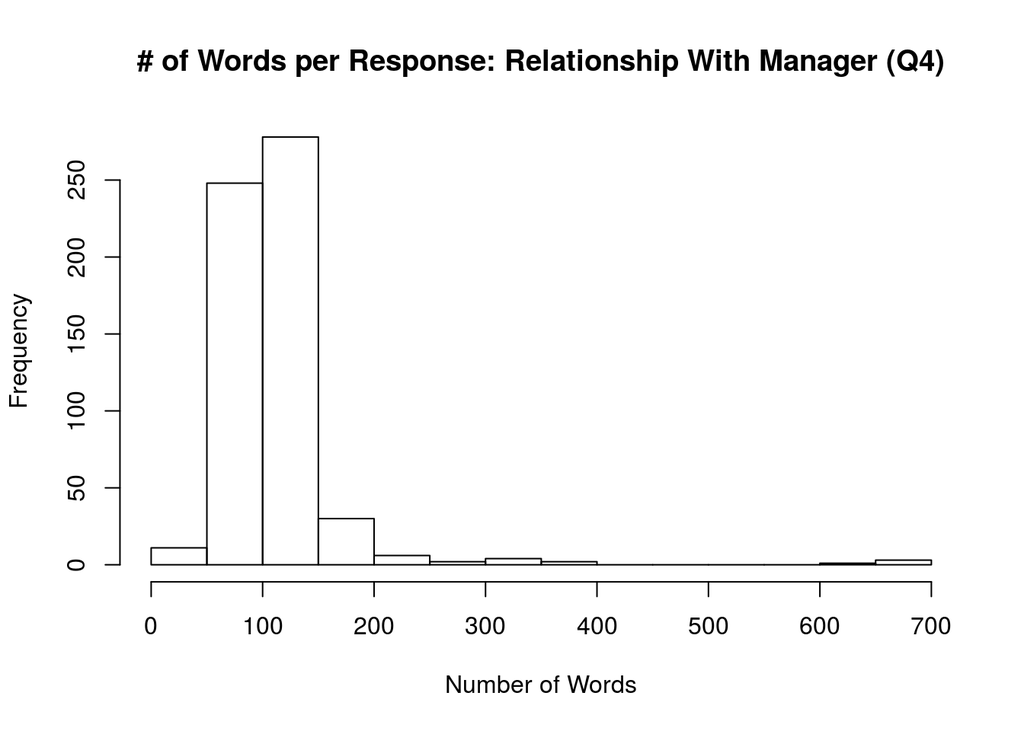

```r
hist(ntoken(responses$Q4), breaks = 20, main = "# of Words per Response: Relationship With Manager (Q4)",
    xlab = "Number of Words")
```

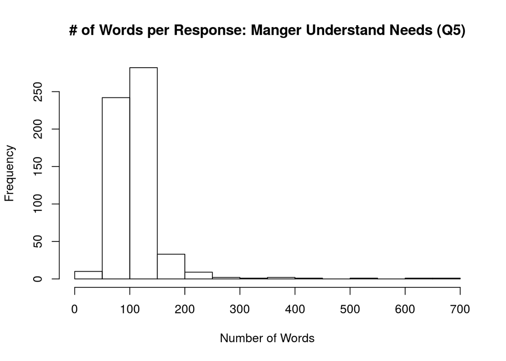

```r
hist(ntoken(responses$Q5), breaks = 20, main = "# of Words per Response: Manger Understand Needs (Q5)",
    xlab = "Number of Words")
```

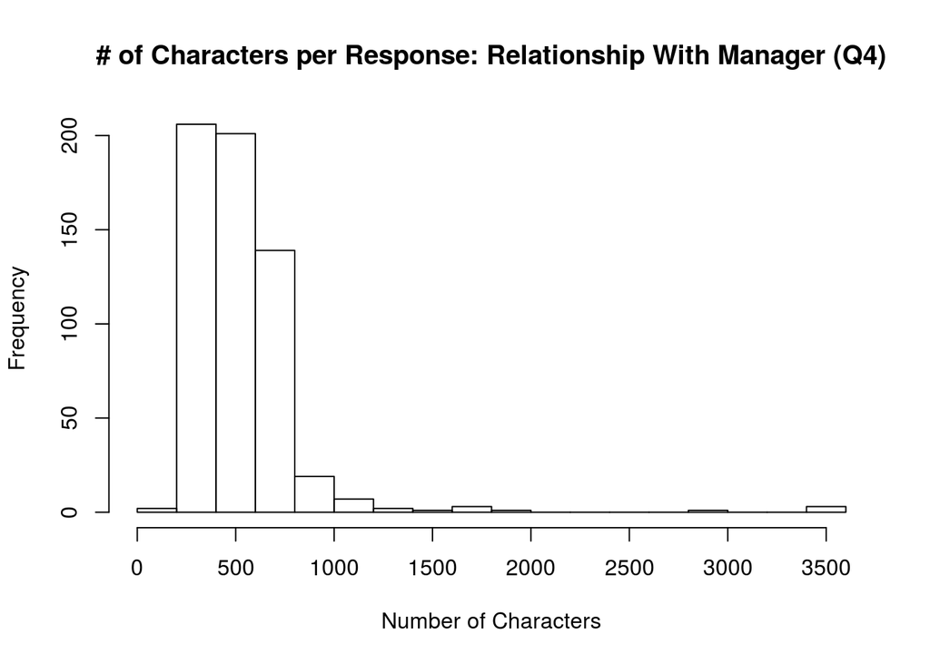

```r
hist(nchar(responses$Q4), breaks = 20, main = "# of Characters per Response: Relationship With Manager (Q4)",
    xlab = "Number of Characters")
```

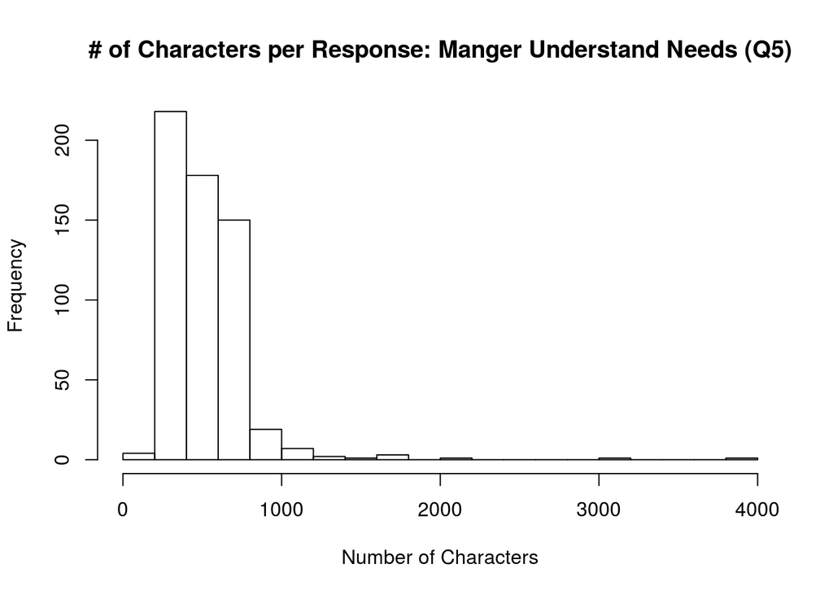

```r
hist(nchar(responses$Q5), breaks = 20, main = "# of Characters per Response: Manger Understand Needs (Q5)",
    xlab = "Number of Characters")
```

Let’s find outliers who responded with less than 10 words.

```r
maxWords <- 10

responses$Q5[which(ntoken(responses$Q5) < maxWords)]
```

```
## [1] "He cannot understand anything always"
```

### Covariates: Explore & Extraction

Before running our analysis, we need to prepare any covariates that we’ll use in our analysis.

First, let’s look at how many responses we have by two attributes (covariates): the gender of the respondee and the gender of his/her manager. These two variables will be our focus on how they impact what topics are covered in the responses.

```r
responses %>% group_by(Q8, Q9) %>% summarise(Count = n())
```

```
## # A tibble: 4 x 3
## # Groups:   Q8 [?]
##       Q8     Q9 Count
##    <chr>  <chr> <int>
## 1 Female Female   147
## 2 Female   Male    49
## 3   Male Female   136
## 4   Male   Male   253
```

Recall, Q8 = Manager (Leader) Gender, Q9 = Gender of Respondee. These two variables look good and do not need any additional data preparation.

Let’s also consider location and occupation. For both of these responses, they were open-ended in which respondents could write in any text. This led to many values.

After examining this list, we were able to create a list of two values: domestic (anywhere in the U.S.) and international (anywhere outside of the U.S.).

```r
non.us <- c("Australia", "Canada", "Colombia", "Ecuador", "Finland", "Greece", "india",
    "India", "INDIA", "Indonesia", "italy", "Nepal", "Phillipines", "Sri Lanka",
    "UK", "Ukraine", "United Kingdom", "united kingdom", "venezuela", "Venezuela")

responses$country <- ifelse(responses$Q7 %in% non.us, "International", "Domestic")

table(responses$country)
```

```
##
##      Domestic International
##           468           117
```

For occupation, we have multiple categories that are sparsely populated for some categories.

Let’s group them into three categories: managment, analyst and entry level.

```r
table(responses$Q13)
```

```
##
##                         Analyst / Associate
##                                         273
## C level executive (CIO, CTO, COO, CMO, Etc)
##                                           4
##                                    Director
##                                          18
##                                 Entry Level
##                                         110
##                                      Intern
##                                           3
##                                     Manager
##                                         149
##                                       Owner
##                                           2
##                            President or CEO
##                                           1
##                              Senior Manager
##                                          22
##                       Senior Vice President
##                                           2
##                              Vice President
##                                           1
```

```r
# start with all values Management
responses$occupation <- "Management"
# replace Analyst level
responses$occupation[responses$Q13 == "Analyst / Associate"] <- "Analyst"
# replace Entry Level
responses$occupation[responses$Q13 %in% c("Entry Level", "Intern")] <- "Entry Level"

table(responses$occupation)
```

```
##
##     Analyst Entry Level  Management
##         273         113         199
```

## Quanteda Text Analysis

### Cleaning

Before running the analysis, we need to do two manual cleanups. These are steps that are unique to this dataset but may be required for any dataset.

First, since we combined both of our questions (Q4 and Q5), let’s first create a character vector that contains our text, aptly named `text`.

Second, let’s remove specific cases

```r
text <- c(responses$Q4, responses$Q5)

## Clean ups remove cases where space not completed after sentence for
## tokenization (e.g. man.he => 'man he')
text <- gsub("[.]", " ", text)

# clean up specific texts
text[79]
```

```
## [1] "He does not do too much to help us he just sits in his office and we have to go to him with some questions  He then solves the problem usually and thats it  he tries to be manipulative but he is not very good at it  We all know he does not respect us much and only hires women because he like…
```

To clean this record, we’ll remove the characters after “basically the survey says…”

```r
text[79] <- substr(text[79], 1, 474)
text[79 + 585] <- substr(text[79 + 585], 1, 551)
```

Or another example includes a user…

```r
text[714]
```

```
## [1] "Most of them can not and will not do our jobs, thats part of why they promote to begin with  It seems the shittier you are at your job on the floor, the more they encourage you to move into supervision here  Its ass backwards  As a result none of us have respect for them                     …
```

who wrote a valid response but then used “nono” to reach the minimum length requirement.

We can similarly remove this text using the `substr()` function.

```r
text[714] <- substr(text[714], 1, 271)  # clean the nononono record
```

Next, let’s create the corpus and add the covariates.

```r
myCorpus <- corpus(text)

# add in the attributes about the responses (for now, just the gender of
# respondee and manager)
docvars(myCorpus, "ManagerGender") <- c(responses$Q8, responses$Q8)
docvars(myCorpus, "SelfGender") <- c(responses$Q9, responses$Q9)

docvars(myCorpus, "Question") <- c(rep("Q4", 585), rep("Q5", 585))
docvars(myCorpus, "Country") <- c(responses$country, responses$country)
docvars(myCorpus, "Occupation") <- c(responses$occupation, responses$occupation)
```

Let’s create our document-feature matrix with only basic preprocessing (standard stop words, unigrams, no stemming).

Recall, the document-feature includes the document-term matrix (counts of each term in each document) along with the covariates (features) we just provided above like the country and occupation of the respondent.

### Tokenize, Stemming, Uni/Bi/Tri-grams, Stop Words (dfm)

Let’s run text pre-processing.

```r
dfm <- dfm(myCorpus, remove = c(stopwords("english")), ngrams = 1L, stem = F, remove_numbers = T,
    remove_punct = T, remove_symbols = T, remove_hyphens = F)

topfeatures(dfm, 25)
```

```
##       leader         work       always           us         need
##         1111         1023          586          567          491
## relationship         good          can      manager         time
##          476          458          445          420          413
##     coaching          job         help   supervisor          get
##          398          398          393          375          359
##         also     problems         like     provides      respect
##          358          329          295          293          290
##         much         well          one          way      provide
##          270          269          266          263          261
```

Let’s explore removing sparse terms.

In addition to removing the standard list of stop words (stopwords(“english”)), we’ve added a list of additional stop words.

```r
extra.stop <- c("always", "will", "can", "job", "us", "get", "also", "much", "well",
    "way", "like", "things", "one", "make", "really", "just", "take", "lot", "even",
    "done", "something", "go", "sure", "makes", "every", "come", "say", "many", "often",
    "see", "little", "want", "though", "without", "going", "takes", "someone", "however",
    "comes", "usually", "may", "office", "thing", "making", "along", "since", "long",
    "back", "similar", "goes", "put", "getting", "another", "keep", "related", "else",
    "now", "seems", "co")

dfm <- dfm(myCorpus, remove = c(stopwords("english"), extra.stop), ngrams = 1L, stem = F,
    remove_numbers = T, remove_punct = T, remove_symbols = T, remove_hyphens = F)

dfm <- dfm_trim(dfm, min_docfreq = 2)

topfeatures(dfm, 25)
```

```
##       leader         work         need relationship         good
##         1111         1023          491          476          458
##      manager         time     coaching         help   supervisor
##          420          413          398          393          375
##     problems     provides      respect      provide         know
##          329          293          290          261          255
##        needs         team      company         feel         give
##          252          249          227          217          216
##      support     concerns         boss      working     training
##          213          203          202          202          198
```

Can you see the differences between the second iteration after we removed the additional stop words?

Let’s plot two word clouds – one as a whole and the second by respondee country.

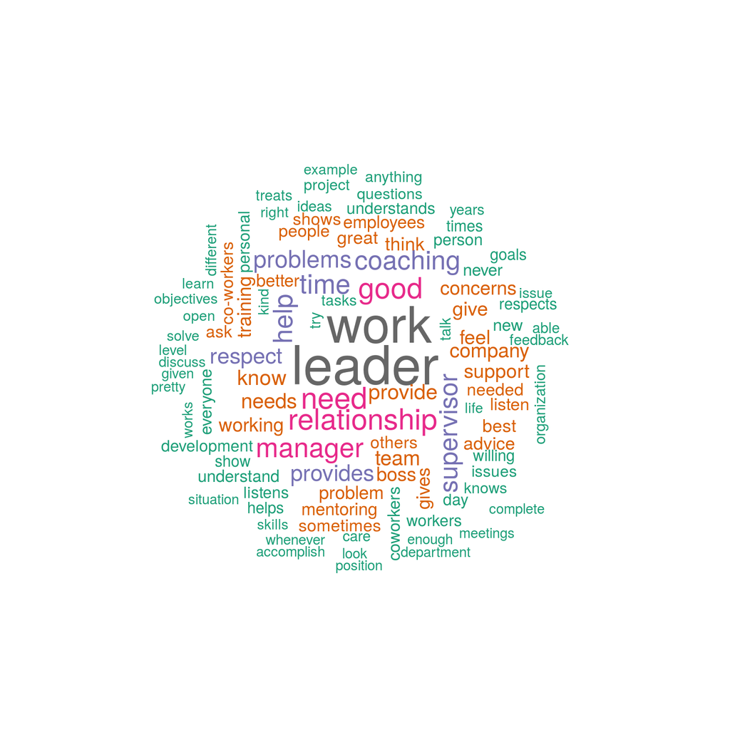

```r
library(RColorBrewer)

textplot_wordcloud(dfm, scale = c(3.5, 0.75), colors = brewer.pal(8, "Dark2"), random.order = F,
    rot.per = 0.1, max.words = 100)
```

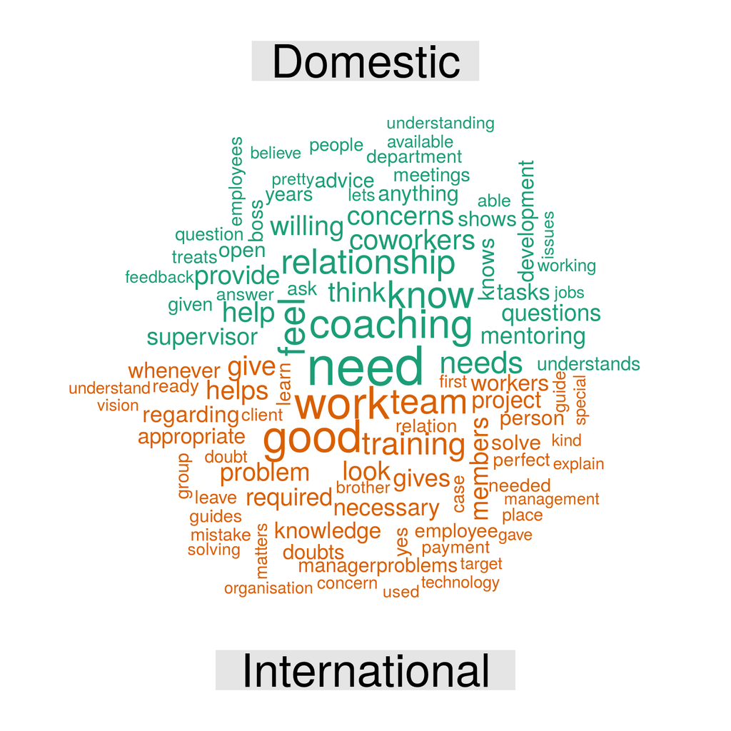

```r
cdfm <- dfm(myCorpus, group = "Country", remove = c(stopwords("english"), extra.stop),
    stem = F, remove_numbers = T, remove_punct = T, remove_symbols = T, remove_hyphens = F)

textplot_wordcloud(cdfm, comparison = T, scale = c(3.5, 0.75), colors = brewer.pal(8,
    "Dark2"), random.order = F, rot.per = 0.1, max.words = 100)
```

This suggest that Domestic participants used “development” more often than International participants. Yet a problem with exploratory words clouds is that they do not measure the difference – especially with statistical inferece. Let’s keep this in mind for when we run topic modeling.

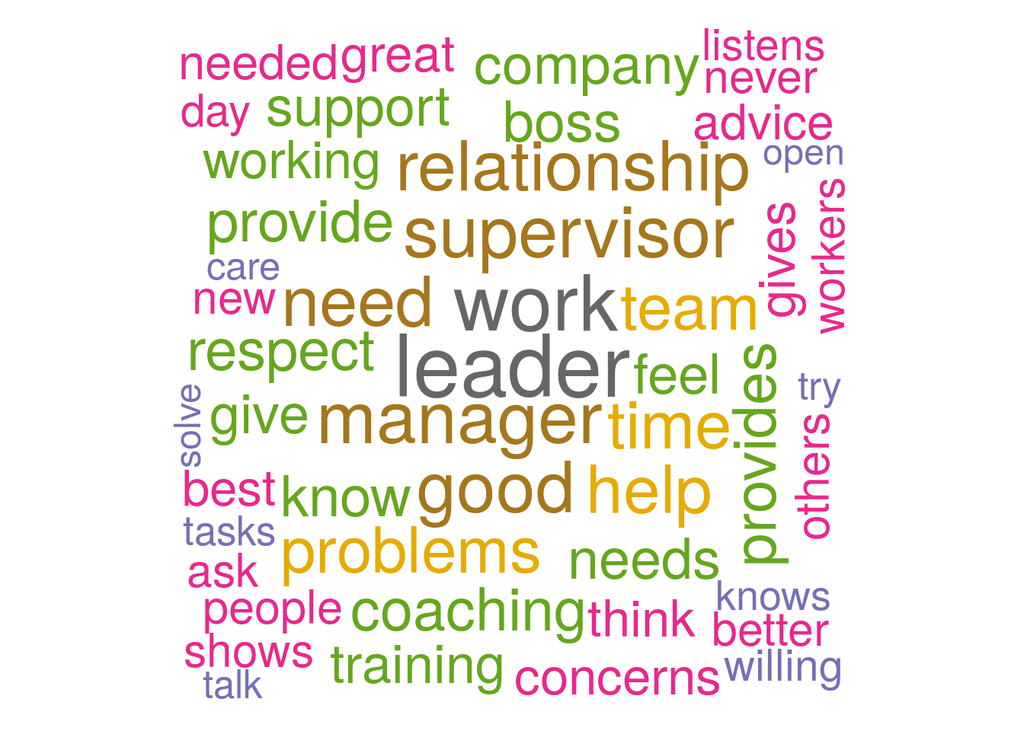

```r
textplot_wordcloud(tfidf(dfm), scale = c(3.5, 0.75), colors = brewer.pal(8, "Dark2"),
    random.order = F, rot.per = 0.1, max.words = 100)
```

We can use word clustering to identify words that co-occur together.

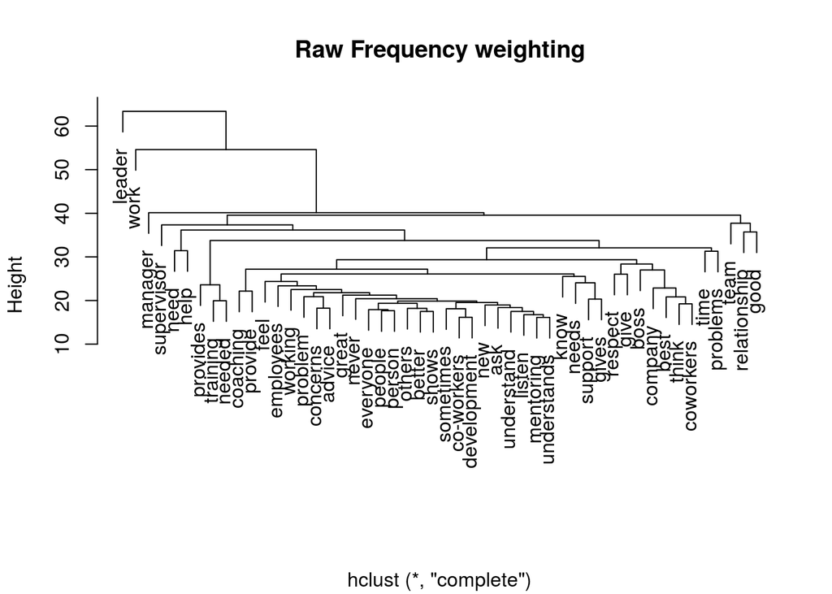

```r
wordDfm <- dfm_sort(dfm_weight(dfm, "frequency"))
wordDfm <- t(wordDfm)[1:50, ]  # because transposed
wordDistMat <- dist(wordDfm)
wordCluster <- hclust(wordDistMat)
plot(wordCluster, xlab = "", main = "Raw Frequency weighting")
```

Another interesting take on this plot is not use the raw frequencies (word counts) but instead use the [TF-IDF](https://en.wikipedia.org/wiki/Tf%E2%80%93idf) weightings, which re-weights the words focusing less on words that are either rarely used or used too frequently.

We can rerun the plot with TF-IDF by changing the “frequency” to “tfidf” in the second line of the code.

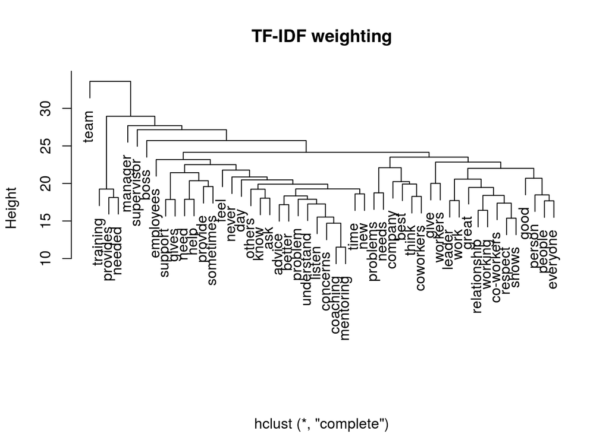

```r
wordDfm <- dfm_sort(dfm_weight(dfm, "tfidf"))
wordDfm <- t(wordDfm)[1:50, ]  # because transposed
wordDistMat <- dist(wordDfm)
wordCluster <- hclust(wordDistMat)
plot(wordCluster, xlab = "", main = "TF-IDF weighting")
```

## Save Image & Libraries Used

```r
save.image(file = "01-datacleaning-exploration.RData")
```